# Seasonal Random Forest

Scott Silverstein

2025-01-08

# Introduction

The Random Forest model for predictive maintenance is designed to help Swire Coca-Cola proactively manage equipment downtime by predicting the likelihood of machine breakdowns on a quarterly basis. By analyzing historical data, including maintenance records, time intervals between breakdowns, and operational factors such as equipment age and maintenance types, the model identifies patterns that can forecast future breakdowns with high accuracy.

This model’s primary objective is to enable more effective resource allocation by pinpointing high-risk quarters. With this quarterly breakdown insight, Swire Coca-Cola can preemptively schedule maintenance, stock essential spare parts, and optimize budget allocations to minimize unplanned downtimes. Ultimately, this predictive approach aims to reduce operational costs, improve production continuity, and ensure timely delivery to meet customer demand.

## Packages

```r
# install.packages("tidyverse")
# install.packages("lubridate")
# install.packages("zoo")
# install.packages("randomForest")
# install.packages("caret")
# install.packages("kintr")
# install.packages("kableExtra")
library(tidyverse)
library(lubridate)
library(zoo)
library(randomForest)
library(caret)
library(knitr)
library(kableExtra)
```

## Data

```r
data = read.csv("IWC_Work_Orders_Extract.csv")
```

# Execution Start and end date information

```r
str(data$EXECUTION_START_DATE)
```

```
##  chr [1:1048575] "5/4/2024" "9/13/2022" "12/21/2022" "7/4/2022" "3/15/2023" ...
```

```r
str(data$EXECUTION_FINISH_DATE)
```

```
##  chr [1:1048575] "5/12/2024" "9/13/2022" "12/21/2022" "7/4/2022" ...
```

```r
summary(data$EXECUTION_START_DATE)
```

```
##    Length     Class      Mode
##   1048575 character character
```

```r
summary(data$EXECUTION_FINISH_DATE)
```

```
##    Length     Class      Mode
##   1048575 character character
```

```r
non_missing_start <- sum(!is.na(data$EXECUTION_START_DATE)) / nrow(data) * 100
non_missing_finish <- sum(!is.na(data$EXECUTION_FINISH_DATE)) / nrow(data) * 100
cat("Non-missing EXECUTION_START_DATE:", non_missing_start, "%\n")
```

```
## Non-missing EXECUTION_START_DATE: 100 %
```

```r
cat("Non-missing EXECUTION_FINISH_DATE:", non_missing_finish, "%\n")
```

```
## Non-missing EXECUTION_FINISH_DATE: 100 %
```

# Feature Engineering

## Convert Date Columns and Extract Year and Quarter

```r
# Convert character dates to Date format
data$EXECUTION_START_DATE <- as.Date(data$EXECUTION_START_DATE, format = "%m/%d/%Y")
data$EXECUTION_FINISH_DATE <- as.Date(data$EXECUTION_FINISH_DATE, format = "%m/%d/%Y")

# Extract year and quarter from EXECUTION_START_DATE
data$execution_year <- year(data$EXECUTION_START_DATE)
data$execution_quarter <- quarter(data$EXECUTION_START_DATE)
```

## Calculate Average Repair Duration and Unplanned Maintenance Proportion

**This step calculates essential entrancement metrics before summarizing the data for quarterly records**

```r
data_viz <- data %>%
  group_by(FUNCTIONAL_AREA_NODE_1_MODIFIED, execution_year, execution_quarter) %>%
  summarize(
    avg_repair_duration = mean(ACTUAL_WORK_IN_MINUTES, na.rm = TRUE),
    unplanned_maintenance_prop = mean(MAINTENANCE_ACTIVITY_TYPE == "Unplanned", na.rm = TRUE),
    records = n()
  ) %>%
  ungroup()
```

# Visualizations

## Quarterly Breakdwon Counts Over time

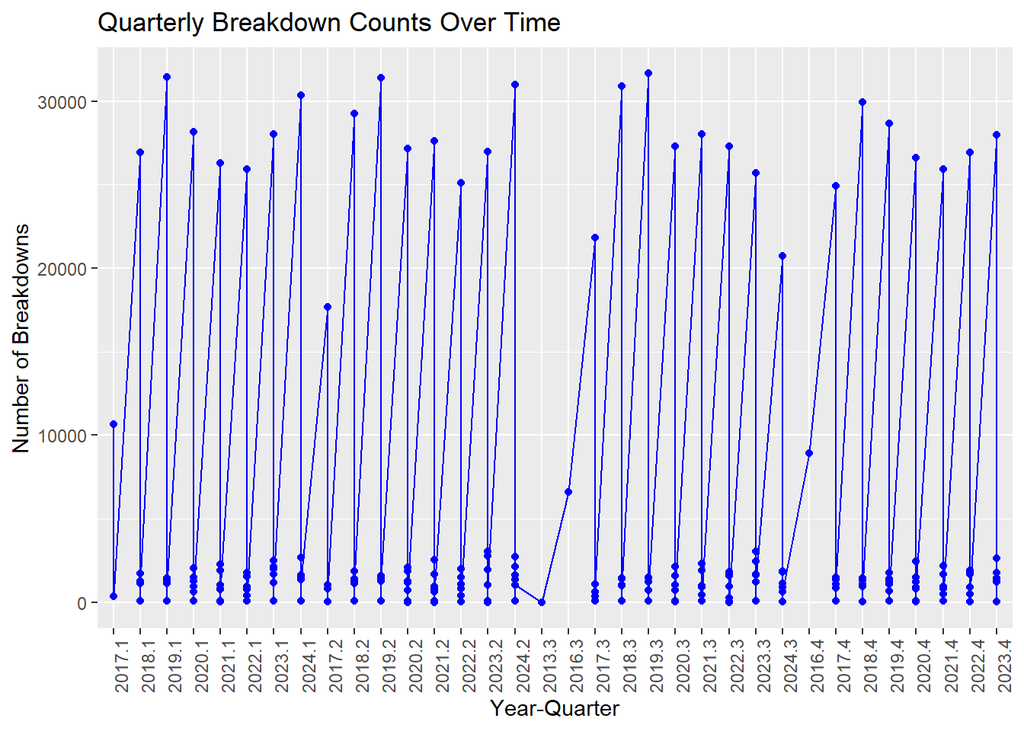

```r
ggplot(data_viz, aes(x = interaction(execution_year, execution_quarter), y = records)) +
  geom_line(group = 1, color = "blue") +
  geom_point(color = "blue") +
  labs(title = "Quarterly Breakdown Counts Over Time",
       x = "Year-Quarter",
       y = "Number of Breakdowns") +
  theme(axis.text.x = element_text(angle = 90, hjust = 1))
```

## Average Repair Duration by Quarter

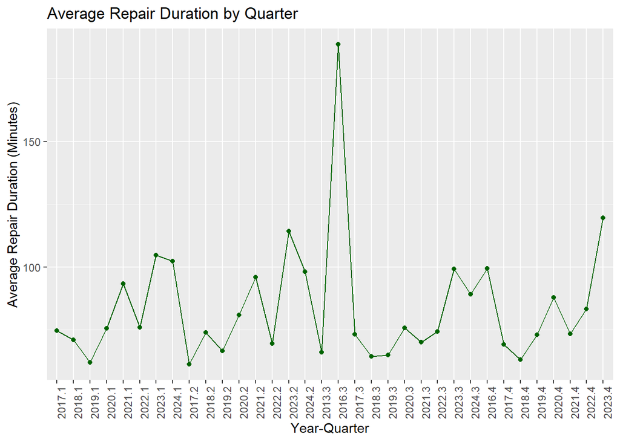

```r
avg_work_duration <- data_viz %>%
  group_by(execution_year, execution_quarter) %>%
  summarize(avg_duration = mean(avg_repair_duration, na.rm = TRUE))

ggplot(avg_work_duration, aes(x = interaction(execution_year, execution_quarter), y = avg_duration)) +
  geom_line(group = 1, color = "darkgreen") +
  geom_point(color = "darkgreen") +
  labs(title = "Average Repair Duration by Quarter",
       x = "Year-Quarter",
       y = "Average Repair Duration (Minutes)") +
  theme(axis.text.x = element_text(angle = 90, hjust = 1))
```

## Breakdown Counts by Quarter for Each Functional Area

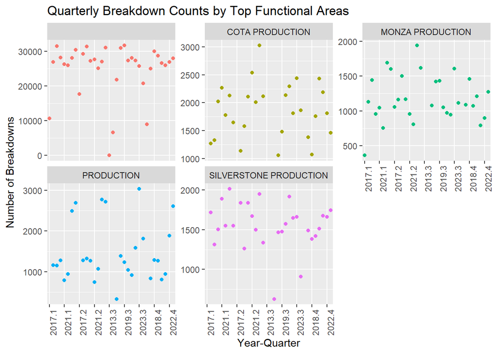

```r
# Find top functional areas based on total breakdowns
top_areas <- data_viz %>%
  group_by(FUNCTIONAL_AREA_NODE_1_MODIFIED) %>%
  summarize(total_breakdowns = sum(records)) %>%
  arrange(desc(total_breakdowns)) %>%
  slice_head(n = 5)

# Filter to include only the top areas
top_data <- data_viz %>%
  filter(FUNCTIONAL_AREA_NODE_1_MODIFIED %in% top_areas$FUNCTIONAL_AREA_NODE_1_MODIFIED)

# Plot breakdown counts by quarter for top functional areas
ggplot(top_data, aes(x = interaction(execution_year, execution_quarter), y = records, color = FUNCTIONAL_AREA_NODE_1_MODIFIED)) +
  geom_line() +
  geom_point() +
  facet_wrap(~ FUNCTIONAL_AREA_NODE_1_MODIFIED, scales = "free_y") +
  labs(title = "Quarterly Breakdown Counts by Top Functional Areas",
       x = "Year-Quarter",
       y = "Number of Breakdowns") +
  theme(axis.text.x = element_text(angle = 90, hjust = 1)) +
  scale_x_discrete(breaks = function(x) x[seq(1, length(x), by = 4)]) +
  theme(legend.position = "none")
```

## Total Breakdowns by Quarter

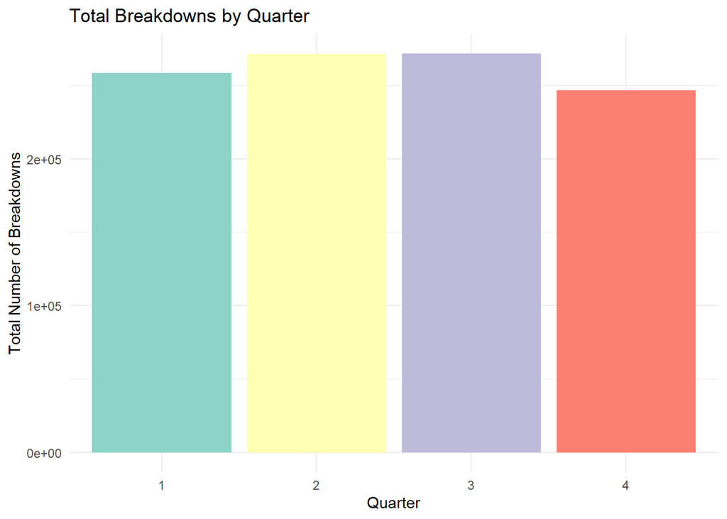

```r
# Create data_viz with records column
data_viz <- data %>%
  group_by(FUNCTIONAL_AREA_NODE_1_MODIFIED, execution_year, execution_quarter) %>%
  summarize(
    avg_repair_duration = mean(ACTUAL_WORK_IN_MINUTES, na.rm = TRUE),
    unplanned_maintenance_prop = mean(MAINTENANCE_ACTIVITY_TYPE == "Unplanned", na.rm = TRUE),
    records = n()  # This column counts the number of breakdowns
  ) %>%
  ungroup()
# Summarize data_viz by quarter
breakdowns_by_quarter <- data_viz %>%
  group_by(execution_quarter) %>%
  summarize(total_breakdowns = sum(records))

# Plot total breakdowns by quarter
ggplot(breakdowns_by_quarter, aes(x = factor(execution_quarter), y = total_breakdowns, fill = factor(execution_quarter))) +
  geom_bar(stat = "identity") +
  labs(title = "Total Breakdowns by Quarter",
       x = "Quarter",
       y = "Total Number of Breakdowns") +
  theme_minimal() +
  scale_fill_brewer(palette = "Set3", guide = FALSE)
```

The bar chart shows the total breakdowns for each quarter across all years, with each quarter having a similar high volume of breakdowns. This indicates that breakdowns are consistently distributed throughout the year, with no quarter standing out as particularly high or low in maintenance demands.

## Heatmap

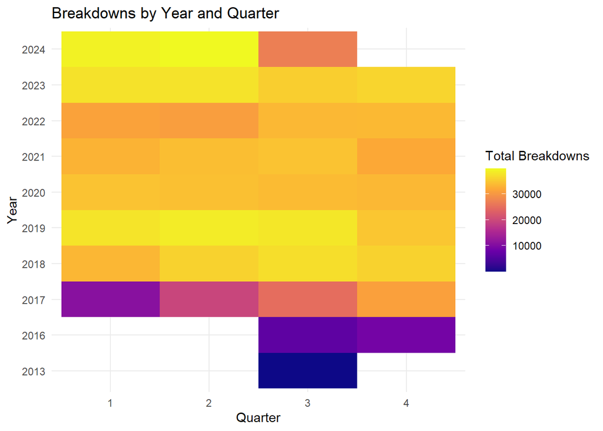

```r
# Summarize data_viz by year and quarter
breakdowns_by_year_quarter <- data_viz %>%
  group_by(execution_year, execution_quarter) %>%
  summarize(total_breakdowns = sum(records))

# Plot heatmap by year and quarter
ggplot(breakdowns_by_year_quarter, aes(x = factor(execution_quarter), y = factor(execution_year), fill = total_breakdowns)) +
  geom_tile() +
  labs(title = "Breakdowns by Year and Quarter",
       x = "Quarter",
       y = "Year",
       fill = "Total Breakdowns") +
  scale_fill_viridis_c(option = "C") +
  theme_minimal()
```

The heatmap shows the total breakdowns by year and quarter, with darker colors representing lower breakdown counts and lighter colors representing higher counts. The pattern reveals consistently high breakdowns in recent years, with notable dips in earlier years like 2016 Q3 and 2017 Q1, indicating potential changes in maintenance needs or operational intensity over time.

## What we learned for marketing

**Modeling Considerations**

These observations suggest a model that incorporates functional area, quarterly breakdown trends, and historical breakdowns to capture patterns in maintenance needs. Lagged features (variables that capture past values of a feature at a specific time interval to help predict future outcomes), moving averages (calculated by averaging a set of past values over a specific time window, smoothing out short-term fluctuations to reveal longer-term trends in the data.), and cumulative breakdown totals over the past quarters could enhance predictive power by reflecting both immediate and long-term maintenance demands. This approach will enable the model to identify high-risk periods and allocate resources efficiently across quarters and functional areas.

# Model Preparation

## Structure data

```r
# Extract year and quarter
data <- data %>%
  mutate(
    execution_year = year(EXECUTION_START_DATE),
    execution_quarter = quarter(EXECUTION_START_DATE)
  )
```

## Aggregate by Quarter

```r
# Summarize data by quarter and functional area
data_model <- data %>%
  group_by(FUNCTIONAL_AREA_NODE_1_MODIFIED, execution_year, execution_quarter) %>%
  summarize(
    records = n(),
    avg_repair_duration = mean(ACTUAL_WORK_IN_MINUTES, na.rm = TRUE),
    unplanned_maintenance_prop = mean(MAINTENANCE_ACTIVITY_TYPE == "Unplanned", na.rm = TRUE)
  ) %>%
  ungroup()
```

## Create Lagged and Moving Average Featrues

```r
# Add lagged features and moving averages
data_model <- data_model %>%
  arrange(FUNCTIONAL_AREA_NODE_1_MODIFIED, execution_year, execution_quarter) %>%
  group_by(FUNCTIONAL_AREA_NODE_1_MODIFIED) %>%
  mutate(
    breakdowns_last_quarter = lag(records, 1),
    breakdowns_same_quarter_last_year = lag(records, 4),
    avg_breakdowns_last_4_quarters = rollmean(records, k = 4, fill = NA, align = "right"),
    total_breakdowns_last_4_quarters = rollsum(records, k = 4, fill = NA, align = "right")
  ) %>%
  ungroup()
```

## Handle Missing Data

```r
# Handle missing values
data_model <- data_model %>%
  mutate(
    breakdowns_last_quarter = ifelse(is.na(breakdowns_last_quarter), 0, breakdowns_last_quarter),
    breakdowns_same_quarter_last_year = ifelse(is.na(breakdowns_same_quarter_last_year), 0, breakdowns_same_quarter_last_year),
    avg_breakdowns_last_4_quarters = ifelse(is.na(avg_breakdowns_last_4_quarters), 0, avg_breakdowns_last_4_quarters),
    total_breakdowns_last_4_quarters = ifelse(is.na(total_breakdowns_last_4_quarters), 0, total_breakdowns_last_4_quarters)
  )
```

## Convert Categorical Variables to factors

```r
# One-hot encode categorical variables if necessary
data_model <- data_model %>%
  mutate(FUNCTIONAL_AREA_NODE_1_MODIFIED = as.factor(FUNCTIONAL_AREA_NODE_1_MODIFIED))
```

```r
names(data_model)
```

```
##  [1] "FUNCTIONAL_AREA_NODE_1_MODIFIED"   "execution_year"
##  [3] "execution_quarter"                 "records"
##  [5] "avg_repair_duration"               "unplanned_maintenance_prop"
##  [7] "breakdowns_last_quarter"           "breakdowns_same_quarter_last_year"
##  [9] "avg_breakdowns_last_4_quarters"    "total_breakdowns_last_4_quarters"
```

# Modeling

## Step 1: Dfine Target Features

```r
# Define the target variable
target <- "records"

# Define features to include all columns except the target
features <- setdiff(names(data_model), target)
```

## Split data into Training and Testing Sets

```r
# Split the data into training and testing sets (70/30 split)
set.seed(123)
train_indices <- sample(seq_len(nrow(data_model)), size = 0.7 * nrow(data_model))
train_data <- data_model[train_indices, c(target, features)]
test_data <- data_model[-train_indices, c(target, features)]
```

## Train Random Forest

```r
# Train the Random Forest model
set.seed(123)
rf_model <- randomForest(
  as.formula(paste(target, "~ .")),
  data = train_data,
  ntree = 100,
  mtry = floor(sqrt(length(features))),
  importance = TRUE
)
# Print basic summary of the model
print(rf_model)
```

```
##
## Call:
##  randomForest(formula = as.formula(paste(target, "~ .")), data = train_data,      ntree = 100, mtry = floor(sqrt(length(features))), importance = TRUE)
##                Type of random forest: regression
##                      Number of trees: 100
## No. of variables tried at each split: 3
##
##           Mean of squared residuals: 1411690
##                     % Var explained: 98.04
```

The Random Forest model is a regression model trained with 100 trees, each split using 3 randomly selected features. The Mean of squared residuals (error measure) is 1,411,690, indicating the average squared difference between predicted and actual values. With 98.04% of variance explained, the model fits the data well, capturing nearly all variability in the target variable (records).

## Evaluate Performance

```r
# Predict on the test data
predictions <- predict(rf_model, newdata = test_data)

# Calculate performance metrics
mae <- mean(abs(predictions - test_data$records))
rmse <- sqrt(mean((predictions - test_data$records)^2))
r_squared <- cor(predictions, test_data$records)^2

# Print metrics
cat("Mean Absolute Error (MAE):", mae, "\n")
```

```
## Mean Absolute Error (MAE): 617.4969
```

```r
cat("Root Mean Squared Error (RMSE):", rmse, "\n")
```

```
## Root Mean Squared Error (RMSE): 1318.315
```

```r
cat("R-squared:", r_squared, "\n")
```

```
## R-squared: 0.9873887
```

### MAE

```r
# Calculate average and median breakdown counts per quarter
avg_quarterly_count <- mean(data_model$records)
median_quarterly_count <- median(data_model$records)

cat("Average Quarterly Breakdown Count:", avg_quarterly_count, "\n")
```

```
## Average Quarterly Breakdown Count: 4809.977
```

```r
cat("Median Quarterly Breakdown Count:", median_quarterly_count, "\n")
```

```
## Median Quarterly Breakdown Count: 1286.5
```

```r
# MAE % of average and median counts
mae <- 617.5
mae_percentage_avg <- (mae / avg_quarterly_count) * 100
mae_percentage_median <- (mae / median_quarterly_count) * 100

cat("MAE as % of Average Quarterly Count:", mae_percentage_avg, "%\n")
```

```
## MAE as % of Average Quarterly Count: 12.8379 %
```

```r
cat("MAE as % of Median Quarterly Count:", mae_percentage_median, "%\n")
```

```
## MAE as % of Median Quarterly Count: 47.99845 %
```

MAE as a Percentage of the Average Quarterly Count (12.84%): This suggests the model’s errors are reasonably low relative to the average breakdown count, indicating good precision for the typical breakdown volume.

MAE as a Percentage of the Median Quarterly Count (48%): This higher percentage shows that while the model performs well on average, it might be less accurate for quarters with lower breakdown counts. This could mean the model is slightly overestimating breakdowns for quarters that experience fewer breakdowns, pulling the MAE up relative to the median.

Overall, with an MAE of around 12.8% of the average quarterly count, the model is quite effective at predicting breakdowns, especially when they are closer to average levels. However, if more precision is needed for lower breakdown quarters, further tuning or a complementary model focusing on those lower counts might improve performance.

### RMSE

```r
rmse <- 1318.3

# Calculate RMSE as a percentage of the average and median quarterly breakdown count
rmse_percentage_avg <- (rmse / avg_quarterly_count) * 100
rmse_percentage_median <- (rmse / median_quarterly_count) * 100

cat("RMSE as % of Average Quarterly Count:", rmse_percentage_avg, "%\n")
```

```
## RMSE as % of Average Quarterly Count: 27.40762 %
```

```r
cat("RMSE as % of Median Quarterly Count:", rmse_percentage_median, "%\n")
```

```
## RMSE as % of Median Quarterly Count: 102.4718 %
```

- RMSE as a Percentage of Average Quarterly Count (27.4%): This suggests that the model’s larger prediction errors are around a quarter of the average quarterly breakdown count, which is acceptable but might indicate room for improvement, especially if high precision is important for decision-making.
- RMSE as a Percentage of Median Quarterly Count (102.5%): This percentage is high, meaning the model’s larger errors are roughly equivalent to or even greater than typical lower breakdown quarters. This suggests that while the model captures overall patterns well, it tends to overestimate or experience larger deviations for quarters with lower breakdown counts.

In summary, while the model performs reasonably well in general (especially on average-sized quarters), the high RMSE relative to the median count suggests it may struggle with quarters that have fewer breakdowns. If predictions for lower-count quarters are important, additional tuning or adjustments to the model may improve its accuracy.

### Feature Importance

```r
# Feature importance
importance_visual <- importance(rf_model)
importance_visual
```

```
##                                      %IncMSE IncNodePurity
## FUNCTIONAL_AREA_NODE_1_MODIFIED    3.0827056     833904850
## execution_year                     0.5634960      20353955
## execution_quarter                 -0.1055181       3463567
## avg_repair_duration                2.3923296      47749346
## unplanned_maintenance_prop         1.4679719     241417781
## breakdowns_last_quarter            6.4040989    2957216659
## breakdowns_same_quarter_last_year  4.1236186    1494828409
## avg_breakdowns_last_4_quarters     5.6098341    2119239655
## total_breakdowns_last_4_quarters   6.6131431    3198547960
```

[figure not shown]

```r
feature_importance <- varImpPlot(rf_model, main = "Feature Importance")
```

```r
feature_importance
```

```
##                                      %IncMSE IncNodePurity
## FUNCTIONAL_AREA_NODE_1_MODIFIED    3.0827056     833904850
## execution_year                     0.5634960      20353955
## execution_quarter                 -0.1055181       3463567
## avg_repair_duration                2.3923296      47749346
## unplanned_maintenance_prop         1.4679719     241417781
## breakdowns_last_quarter            6.4040989    2957216659
## breakdowns_same_quarter_last_year  4.1236186    1494828409
## avg_breakdowns_last_4_quarters     5.6098341    2119239655
## total_breakdowns_last_4_quarters   6.6131431    3198547960
```

## Model 2

### Log Transformation

```r
# Create a separate copy for the new model transformations
data_model_transformed <- data_model

# Apply transformations on the new copy
data_model_transformed$log_records <- log1p(data_model_transformed$records)  # log1p handles zero values safely
```

### Interaction term

```r
data_model_transformed$interaction_repair_unplanned <- data_model_transformed$avg_repair_duration * data_model_transformed$unplanned_maintenance_prop
```

### Polynomial

```r
data_model_transformed$breakdowns_last_quarter_squared <- data_model_transformed$breakdowns_last_quarter^2
```

## features

```r
# Define the new target variable and feature set
new_target <- "log_records"
new_features <- c(
  "FUNCTIONAL_AREA_NODE_1_MODIFIED", "avg_repair_duration", "unplanned_maintenance_prop",
  "breakdowns_last_quarter", "breakdowns_same_quarter_last_year",
  "avg_breakdowns_last_4_quarters", "total_breakdowns_last_4_quarters",
  "interaction_repair_unplanned", "breakdowns_last_quarter_squared"
)
```

## Split Data

```r
# Split the transformed data into training and testing sets (70/30 split)
set.seed(123)
train_indices <- sample(seq_len(nrow(data_model_transformed)), size = 0.7 * nrow(data_model_transformed))
train_data_new <- data_model_transformed[train_indices, c(new_target, new_features)]
test_data_new <- data_model_transformed[-train_indices, c(new_target, new_features)]
```

### Models

```r
# Train the rf model with the new target and features
set.seed(123)
rf_model_new <- randomForest(
  as.formula(paste(new_target, "~ .")),
  data = train_data_new,
  ntree = 100,
  mtry = floor(sqrt(length(new_features))),
  importance = TRUE
)
```

### Predictions

```r
# Predict on the test set
log_predictions <- predict(rf_model_new, newdata = test_data_new)

# Transform predictions back to original scale
predictions <- expm1(log_predictions)
```

### Performance

```r
# Reconfirm test indices
test_indices <- setdiff(seq_len(nrow(data_model_transformed)), train_indices)

# Extract records from the original dataset for these indices
original_records <- data_model$records[test_indices]

# Double-check lengths
cat("Length of predictions:", length(predictions), "\n")
```

```
## Length of predictions: 66
```

```r
cat("Length of original_records:", length(original_records), "\n")
```

```
## Length of original_records: 66
```

```r
# Calculate performance metrics on the original scale
mae_new <- mean(abs(predictions - original_records))
rmse_new <- sqrt(mean((predictions - original_records)^2))
r_squared_new <- cor(predictions, original_records)^2

# Print the results
cat("New Model Mean Absolute Error (MAE):", mae_new, "\n")
```

```
## New Model Mean Absolute Error (MAE): 750.0007
```

```r
cat("New Model Root Mean Squared Error (RMSE):", rmse_new, "\n")
```

```
## New Model Root Mean Squared Error (RMSE): 1649.243
```

```r
cat("New Model R-squared:", r_squared_new, "\n")
```

```
## New Model R-squared: 0.9797028
```

### MAE

```r
# Calculate MAE percentage for the new model
mae_percentage_avg_new <- (mae_new / avg_quarterly_count) * 100
mae_percentage_median_new <- (mae_new / median_quarterly_count) * 100

# Print results
cat("New Model MAE as % of Average Quarterly Count:", mae_percentage_avg_new, "%\n")
```

```
## New Model MAE as % of Average Quarterly Count: 15.59261 %
```

```r
cat("New Model MAE as % of Median Quarterly Count:", mae_percentage_median_new, "%\n")
```

```
## New Model MAE as % of Median Quarterly Count: 58.29776 %
```

The new model’s Mean Absolute Error (MAE) is approximately 15.6% of the average quarterly breakdown count and 58.3% of the median quarterly breakdown count. This indicates that while the model performs reasonably well on average, its errors are relatively high for quarters with fewer breakdowns, suggesting it still may struggle with accurately predicting low-count quarters.

## Feature Importance

```r
# Calculate feature importance
importance_values <- importance(rf_model_new)

# Print the importance values
print(importance_values)
```

```
##                                    %IncMSE IncNodePurity
## FUNCTIONAL_AREA_NODE_1_MODIFIED   6.087344    102.778895
## avg_repair_duration               3.125802      3.653356
## unplanned_maintenance_prop        4.348483     29.047597
## breakdowns_last_quarter           8.073707    172.853129
## breakdowns_same_quarter_last_year 1.914769      5.067208
## avg_breakdowns_last_4_quarters    4.554085     79.414636
## total_breakdowns_last_4_quarters  3.524705     58.320027
## interaction_repair_unplanned      4.618813     10.721354
## breakdowns_last_quarter_squared   6.822334    117.456566
```

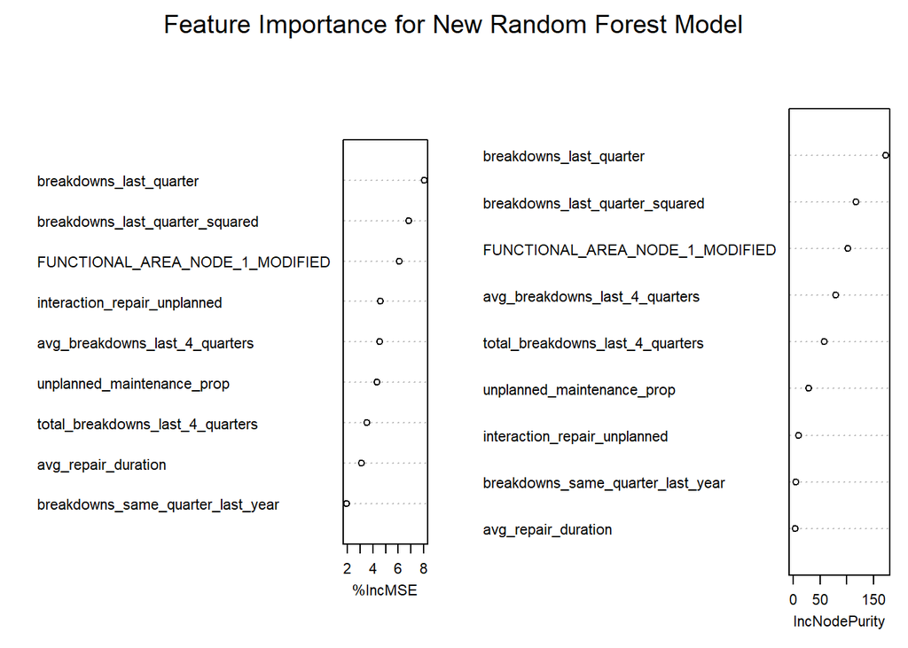

```r
# Plot feature importance
varImpPlot(rf_model_new, main = "Feature Importance for New Random Forest Model",
           n.var = min(10, nrow(importance(rf_model_new))),   # Show top 10 features if too many
           cex = 0.7,                                        # Adjust text size if needed
           las = 2)                                          # Make y-axis labels vertical
```

The Feature Importance Plot from the Random Forest model shows which variables have the most influence on predicting quarterly breakdown counts.

Top Features:

breakdowns_last_quarter and breakdowns_last_quarter_squared: These variables are the most important, indicating that recent breakdown counts (especially the previous quarter) have a strong predictive impact on future breakdowns. FUNCTIONAL_AREA_NODE_1_MODIFIED: This feature, which likely represents the functional area or department, is also highly influential. This suggests that the likelihood of breakdowns varies significantly across different functional areas. Other Influential Features:

avg_breakdowns_last_4_quarters and total_breakdowns_last_4_quarters: These features, representing breakdown patterns over the last year, also contribute to the prediction. They show that past trends over several quarters help in forecasting future breakdowns. unplanned_maintenance_prop: The proportion of unplanned maintenance events affects breakdown counts, implying that areas with more unplanned maintenance events are more likely to experience breakdowns. Less Impactful Features:

Features like avg_repair_duration and breakdowns_same_quarter_last_year have lower importance. While they provide some predictive value, they are not as influential as the more recent breakdown history or functional area. In summary, the model emphasizes recent breakdown counts and functional area as the strongest indicators for predicting quarterly breakdown counts. This insight can guide maintenance scheduling by prioritizing areas with high recent breakdown counts and tailoring strategies for different functional areas.

## Feature Importance By Quarter

### Loop and train

```r
# Loop over each quarter, train a model, and capture feature importance
quarterly_importance <- list()

for (q in 1:4) {
  # Filter data for each quarter
  data_q <- data_model_transformed %>% filter(execution_quarter == q)

  # Train a Random Forest model on the data for this quarter
  rf_q <- randomForest(
    as.formula(paste(new_target, "~ .")),
    data = data_q,
    ntree = 100,
    mtry = floor(sqrt(length(new_features))),
    importance = TRUE
  )

  # Get feature importance and store it with quarter information
  importance_q <- as.data.frame(importance(rf_q))
  importance_q$Feature <- rownames(importance_q)
  importance_q$Quarter <- q

  quarterly_importance[[q]] <- importance_q
}

# Combine importance data for all quarters
quarterly_importance_df <- do.call(rbind, quarterly_importance)

# Convert Quarter to a factor to make it a discrete variable for plotting
quarterly_importance_df$Quarter <- as.factor(quarterly_importance_df$Quarter)

# Filter out the target variable 'records' from the importance data frame, if present
quarterly_importance_df <- quarterly_importance_df %>%
  filter(Feature != "records")

# Calculate the average importance of each feature across quarters
avg_importance <- quarterly_importance_df %>%
  group_by(Feature) %>%
  summarize(mean_importance = mean(`%IncMSE`, na.rm = TRUE))

# Merge back to order by mean importance and reorder features
quarterly_importance_df <- quarterly_importance_df %>%
  left_join(avg_importance, by = "Feature") %>%
  mutate(Feature = reorder(Feature, -mean_importance))
```

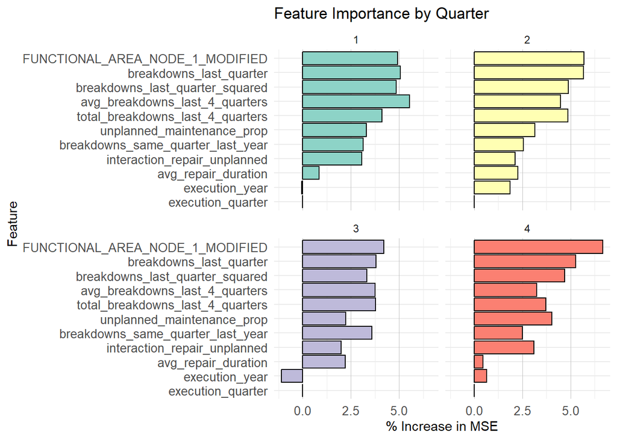

```r
# Create the plot with facet_wrap for each quarter
ggplot(quarterly_importance_df, aes(x = reorder(Feature, `%IncMSE`), y = `%IncMSE`, fill = as.factor(Quarter))) +
  geom_bar(stat = "identity", position = "dodge", color = "black") +
  coord_flip() +
  labs(
    title = "Feature Importance by Quarter",
    x = "Feature",
    y = "% Increase in MSE",
    fill = "Quarter"
  ) +
  facet_wrap(~ Quarter, ncol = 2) +  # Facet by Quarter with 2 columns
  theme_minimal() +
  scale_fill_brewer(palette = "Set3") +
  theme(
    axis.text.y = element_text(size = 10, hjust = 1),
    axis.text.x = element_text(size = 10),
    legend.position = "none",
    panel.grid.major.x = element_line(color = "grey", size = 0.2)
  )
```

### Data Dictionary to clarify importance

```r
# Create a data frame for the data dictionary
data_dictionary <- data.frame(
  Feature = c(
    "FUNCTIONAL_AREA_NODE_1_MODIFIED", "breakdowns_last_quarter_squared", "breakdowns_last_quarter",
    "total_breakdowns_last_4_quarters", "avg_breakdowns_last_4_quarters", "unplanned_maintenance_prop",
    "interaction_repair_unplanned", "breakdowns_same_quarter_last_year", "avg_repair_duration",
    "execution_quarter", "execution_year", "records"
  ),
  Description = c(
    "Primary functional area where the breakdowns are recorded, representing different production areas.",
    "Square of the breakdown count from the previous quarter, highlighting recent significant changes in breakdowns.",
    "Breakdown count from the previous quarter, capturing immediate past performance for trend analysis.",
    "Cumulative breakdowns over the last four quarters, providing insight into yearly maintenance trends.",
    "Average breakdowns over the last four quarters, giving a smoother view of the breakdown pattern per year.",
    "Proportion of maintenance events that were unplanned, indicating responsiveness or unexpected failures.",
    "Interaction term capturing relationship between average repair duration and unplanned maintenance proportion.",
    "Breakdown count in the same quarter of the previous year, indicating seasonal or cyclical patterns.",
    "Average duration of repair in minutes, showing the effort or complexity involved in resolving breakdowns.",
    "Quarter of execution (1 to 4), indicating seasonality and temporal patterns in breakdown occurrences.",
    "Year of execution, providing a timeline for tracking changes and improvements over time.",
    "Target variable representing the count of breakdowns for each quarter in each functional area, serving as the primary output for predictive modeling."
  )
)

# Display the table using knitr::kable for a clean look in R Markdown
kable(data_dictionary, caption = "Data Dictionary for Model Features")
```

Data Dictionary for Model Features

| Feature | Description |
| --- | --- |
| FUNCTIONAL_AREA_NODE_1_MODIFIED | Primary functional area where the breakdowns are recorded, representing different production areas. |
| breakdowns_last_quarter_squared | Square of the breakdown count from the previous quarter, highlighting recent significant changes in breakdowns. |
| breakdowns_last_quarter | Breakdown count from the previous quarter, capturing immediate past performance for trend analysis. |
| total_breakdowns_last_4_quarters | Cumulative breakdowns over the last four quarters, providing insight into yearly maintenance trends. |
| avg_breakdowns_last_4_quarters | Average breakdowns over the last four quarters, giving a smoother view of the breakdown pattern per year. |
| unplanned_maintenance_prop | Proportion of maintenance events that were unplanned, indicating responsiveness or unexpected failures. |
| interaction_repair_unplanned | Interaction term capturing relationship between average repair duration and unplanned maintenance proportion. |
| breakdowns_same_quarter_last_year | Breakdown count in the same quarter of the previous year, indicating seasonal or cyclical patterns. |
| avg_repair_duration | Average duration of repair in minutes, showing the effort or complexity involved in resolving breakdowns. |
| execution_quarter | Quarter of execution (1 to 4), indicating seasonality and temporal patterns in breakdown occurrences. |
| execution_year | Year of execution, providing a timeline for tracking changes and improvements over time. |
| records | Target variable representing the count of breakdowns for each quarter in each functional area, serving as the primary output for predictive modeling. |

**Interpretation**

*Top Features Consistent Across Quarters:* The features FUNCTIONAL_AREA_NODE_1_MODIFIED, breakdowns_last_quarter_squared, and breakdowns_last_quarter consistently show high importance across all quarters, indicating that historical breakdown data and the specific functional area are strong predictors of future breakdowns.

*Seasonal Variation in Importance:* Some features show fluctuating importance across quarters. For instance, unplanned_maintenance_prop is more important in Q1 and Q4, while interaction_repair_unplanned varies throughout the year. This suggests that certain maintenance patterns or reactive behaviors impact breakdowns differently depending on the time of year.

*Lower Importance of Time-Based Features:* execution_year and execution_quarter show low importance across all quarters, indicating that breakdown patterns are not directly tied to the specific year or quarter. This suggests that seasonal trends alone do not fully explain the variation in breakdowns.

**Relevance to Stakeholders** For stakeholders, the model demonstrates that:

*Historical Data Drives Predictions:* The most influential features relate to past breakdowns, supporting a proactive maintenance approach. Knowing that breakdowns in the last quarter are highly predictive of current issues may encourage regular, data-informed check-ups.

*Functional Area Significance:* The functional area of equipment is consistently crucial, suggesting that breakdown likelihood varies significantly by area. This insight can guide resource allocation to high-risk areas.

*Quarter-Specific Maintenance Strategy:* With some features showing seasonal shifts, stakeholders may adopt flexible maintenance practices that align with quarterly variations. For example, increased focus on unplanned maintenance in Q1 and Q4 could reduce unexpected breakdowns.

**Overall Value**

While this visualization reinforces the predictive power of certain features, it provides limited actionable insights specifically tied to quarters. To enhance its value, stakeholders might focus on quarterly maintenance planning for high-risk areas based on this model’s insights. However, if a more nuanced understanding of seasonal trends is required, additional analysis or a deeper focus on quarterly-specific models might be beneficial.